# Modeling with Data in the Tidyverse

## Predicting house price using size & condition

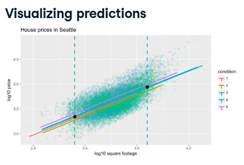

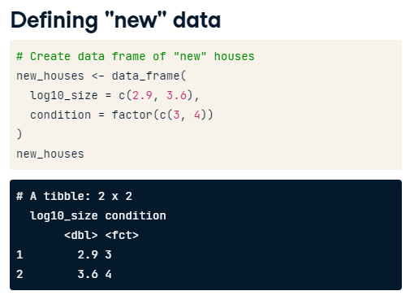

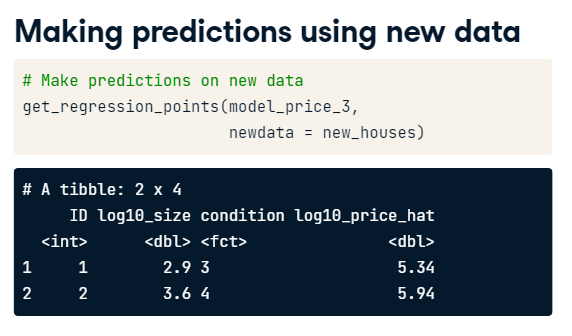

**Making predictions using size and waterfront**

Using your model for `log10_price` as a function of `log10_size` and the binary variable `waterfront`, let’s make some predictions! Say you have the two following “new” houses, what would you predict their prices to be *in dollars*?

- House A: `log10_size = 2.9` that has a view of the waterfront
- House B: `log10_size = 3.1` that does not have a view of the waterfront

We make the corresponding visual predictions below:

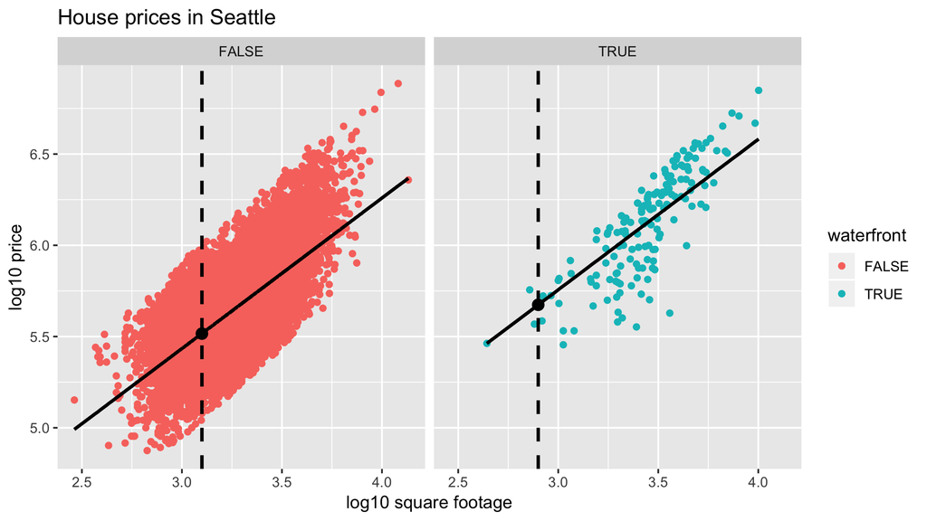

```r
# Get regression table
get_regression_table(model_price_4)
```

```
## # A tibble: 3 x 7
##   term           estimate std_error statistic p_value lower_ci upper_ci
##   <chr>             <dbl>     <dbl>     <dbl>   <dbl>    <dbl>    <dbl>
## 1 intercept         2.96      0.02      146.        0    2.92     3.00
## 2 log10_size        0.825     0.006     134.        0    0.813    0.837
## 3 waterfrontTRUE    0.322     0.013      24.5       0    0.296    0.348
```

```r
# Prediction for House A
10^(2.96 + 0.825 * 2.9 + 0.322)
```

```
## [1] 472606.8
```

```r
# Prediction for House B
10^(2.96 + 0.825 * 3.1)
```

```
## [1] 329230.5
```

Yay! Your modeling toolbox is getting quite extensive! Let’s now automate this!

**Automating predictions on “new” houses**

Let’s now repeat what you did in the last exercise, but in an automated fashion assuming the information on these “new” houses is saved in a dataframe.

Your model for `log10_price` as a function of `log10_size` and the binary variable `waterfront` (`model_price_4`) is available in your workspace, and so is `new_houses_2`, a dataframe with data on 2 new houses. While not so beneficial with only 2 “new” houses, this will save a lot of work if you had 2000 “new” houses.

```r
new_houses_2 <- tibble(log10_size = c(2.9, 3.1), waterfront = c(TRUE, FALSE))

# View the "new" houses
new_houses_2
```

```
## # A tibble: 2 x 2
##   log10_size waterfront
##        <dbl> <lgl>
## 1        2.9 TRUE
## 2        3.1 FALSE
```

```r
# Get predictions on "new" houses
get_regression_points(model_price_4, newdata = new_houses_2)
```

```
## # A tibble: 2 x 4
##      ID log10_size waterfront log10_price_hat
##   <int>      <dbl> <lgl>                <dbl>
## 1     1        2.9 TRUE                  5.67
## 2     2        3.1 FALSE                 5.52
```

```r
# Get predictions price_hat in dollars on "new" houses
get_regression_points(model_price_4, newdata = new_houses_2) %>%
  mutate(price_hat = 10^log10_price_hat)
```

```
## # A tibble: 2 x 5
##      ID log10_size waterfront log10_price_hat price_hat
##   <int>      <dbl> <lgl>                <dbl>     <dbl>
## 1     1        2.9 TRUE                  5.67   472063.
## 2     2        3.1 FALSE                 5.52   328095.
```

Predictions of $472,000 and $328,000! Exceptional! You’re done with the multiple regression chapter, and now you’re onto model assessment and selection!

## Model selection and assessment

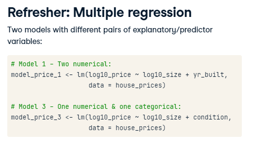

**Refresher: sum of squared residuals** Let’s remind you how to compute the sum of squared residuals. You’ll do this for two models.

```r
# Model 2
model_price_2 <- lm(log10_price ~ log10_size + bedrooms,
                    data = house_prices)

# Calculate squared residuals
get_regression_points(model_price_2) %>%
  mutate(sq_residuals = residual^2) %>%
  summarize(sum_sq_residuals = sum(sq_residuals))
```

```
## # A tibble: 1 x 1
##   sum_sq_residuals
##              <dbl>
## 1             605.
```

```r
# Model 4
model_price_4 <- lm(log10_price ~ log10_size + waterfront,
                    data = house_prices)

# Calculate squared residuals
get_regression_points(model_price_4) %>%
  mutate(sq_residuals = residual^2) %>%
  summarize(sum_sq_residuals = sum(sq_residuals))
```

```
## # A tibble: 1 x 1
##   sum_sq_residuals
##              <dbl>
## 1             599.
```

Wonderful! Let’s use these two measures of model assessment to choose between these two models, or in other words, perform model selection!

**Which model to select?**

Based on these two values of the sum of squared residuals, which of these two models do you think is “better”, and hence which would you select?

- `model_price_2` that uses `log10_size` and `bedrooms`?
- `model_price_4` that uses `log10_size` and `waterfront`?

Since `model_price_4`’s value was lower at 599, select this one.

Given the choice of just these two models, the evidence suggests using size and waterfront yield a better fit, so you should choose this one!

**Assessing model fit with R-squared**

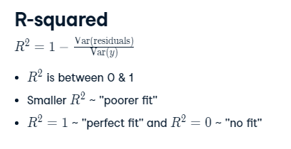

- it is a mathematical fact that $Var_{(y)} \geq Var_{(residuals)}$

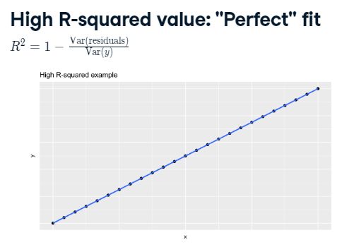

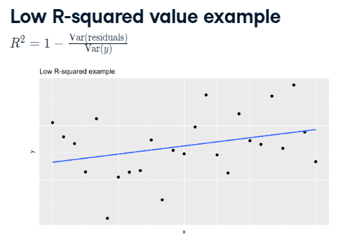

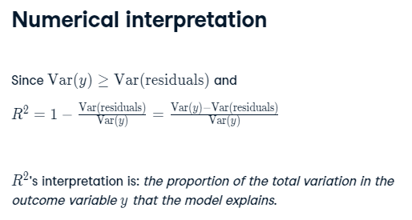

**Computing the R-squared of a model**

Let’s compute the $R^2$ summary value for the two numerical explanatory/predictor variable model you fit in the Chapter 3, price as a function of size and the number of bedrooms.

Recall that $R^2$ can be calculated as:

$1 - \frac{Var_{(residuals)}}{Var_{(y)}}$

```r
# Fit model
model_price_2 <- lm(log10_price ~ log10_size + bedrooms,
                    data = house_prices)

# Get fitted/values & residuals, compute R^2 using residuals
get_regression_points(model_price_2) %>%
  summarize(r_squared = 1 - var(residual) / var(log10_price))
```

```
## # A tibble: 1 x 1
##   r_squared
##       <dbl>
## 1     0.465
```

Nice job! You observed an R-squared value of 0.465, which means that 46.5% of the total variability of the outcome variable log base 10 price can be explained by this model.

**Comparing the R-squared of two models**

Let’s now compute $R^2$ for the one numerical and one categorical explanatory/predictor variable model you fit in the Chapter 3, price as a function of size and whether the house had a view of the `waterfront`, and compare its $R^2$ with the one you just computed.

```r
# Fit model
model_price_4 <- lm(log10_price ~ log10_size + waterfront,
                    data = house_prices)

# Get fitted/values & residuals, compute R^2 using residuals
get_regression_points(model_price_4) %>%
  summarize(r_squared = 1 - var(residual) / var(log10_price))
```

```
## # A tibble: 1 x 1
##   r_squared
##       <dbl>
## 1     0.470
```

Since `model_price_4` had a higher $R^2$ of 0.470, it “fit” the data better.

Since using waterfront explained a higher proportion of the total variance of the outcome variable than using the number of bedrooms, using waterfront in our model is preferred.

## Assessing predictions with RMSE

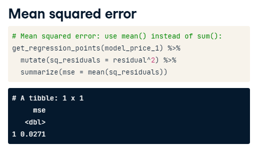

$RMSE$ = typical prediction error the model will make that matches units of outcome variable $y$

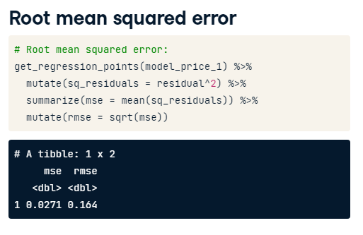

- you can only assess accuracy of predictions (i.e. $RMSE$) if you have access to the observed value $y$

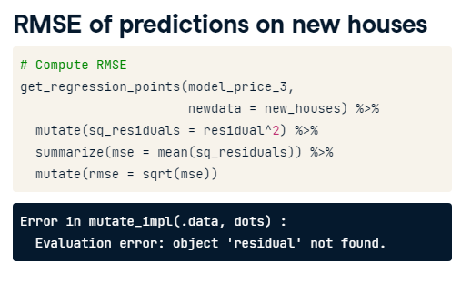

**Computing the MSE & RMSE of a model**

Just as you did earlier with $R^2$, which is a measure of model fit, let’s now compute the root mean square error (RMSE) of our models, which is a commonly used measure of preditive error. Let’s use the model of price as a function of size and number of bedrooms.

The model is available in your workspace as `model_price_2`.

```r
# Get all residuals, square them, and take mean
get_regression_points(model_price_2) %>%
  mutate(sq_residuals = residual^2) %>%
  summarize(mse = mean(sq_residuals))
```

```
## # A tibble: 1 x 1
##      mse
##    <dbl>
## 1 0.0280
```

```r
# Get all residuals, square them, take the mean and square root
get_regression_points(model_price_2) %>%
  mutate(sq_residuals = residual^2) %>%
  summarize(mse = mean(sq_residuals)) %>%
  mutate(rmse = sqrt(mse))
```

```
## # A tibble: 1 x 2
##      mse  rmse
##    <dbl> <dbl>
## 1 0.0280 0.167
```

Woo hoo! The RMSE is 0.167. You can think of this as the “typical” prediction error this model makes.

**Comparing the RMSE of two models**

As you did using the sum of squared residuals and $R^2$, let’s once again assess and compare the quality of your two models using the root mean squared error (RMSE). Note that RMSE is more typically used in prediction settings than explanatory settings.

`model_price_2` and `model_price_4` are available in your workspace.

```r
# MSE and RMSE for model_price_2
get_regression_points(model_price_2) %>%
  mutate(sq_residuals = residual^2) %>%
  summarize(mse = mean(sq_residuals), rmse = sqrt(mean(sq_residuals)))
```

```
## # A tibble: 1 x 2
##      mse  rmse
##    <dbl> <dbl>
## 1 0.0280 0.167
```

```r
# MSE and RMSE for model_price_4
get_regression_points(model_price_4) %>%
  mutate(sq_residuals = residual^2) %>%
  summarize(mse = mean(sq_residuals), rmse = sqrt(mean(sq_residuals)))
```

```
## # A tibble: 1 x 2
##      mse  rmse
##    <dbl> <dbl>
## 1 0.0277 0.166
```

Since `model_price_4` had a lower rmse of 0.166, this is suggestive that this model has better predictive power.

RMSE can be thought of as the ‘typical’ error a predicive model will make.

## Validation set prediction framework

**Validation set approach**

Use two independent datasets to:

1. train/fit your data
2. evaluate your model’s predictive power i.e. validate your model

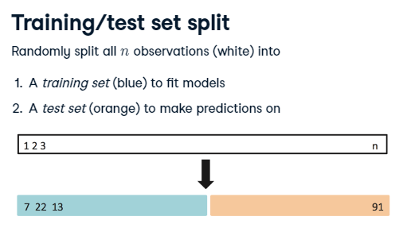

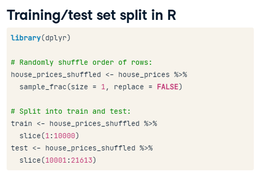

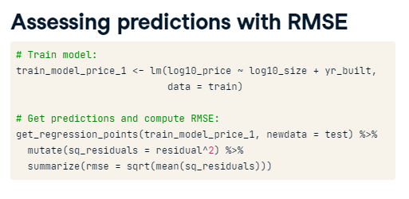

**Fitting model to training data**

It’s time to split your data into a *training* set to fit a model and a separate test set to evaluate the predictive power of the model. Before making this split however, we first sample 100% of the rows of `house_prices` *without* replacement and assign this to `house_prices_shuffled`. This has the effect of “shuffling” the rows, thereby ensuring that the training and test sets are *randomly* sampled.

```r
# Set random number generator seed value for reproducibility
set.seed(76)

# Randomly reorder the rows
house_prices_shuffled <- house_prices %>%
  sample_frac(size = 1, replace = FALSE)

# Train/test split
train <- house_prices_shuffled %>%
  slice(1:10000)
test <- house_prices_shuffled %>%
  slice(10001:21613)

# Fit model to training set
train_model_2 <- lm(log10_price ~ log10_size + bedrooms, data = train)
```

Fabulous! Since you’ve fit/trained the predictive model on the training set, let’s now apply it to the test set to make predictions!

**Predicting on test data**

Now that you’ve trained the model on the `train` set, let’s apply the model to the `test` data, make predictions, and evaluate the predictions. Recall that having a separate `test` set here simulates the gathering of a “new” independent dataset to test our model’s predictive performance on.

The datasets `train` and `test`, and the trained model, `train_model_2` are available in your workspace.

```r
# Make predictions on test set
get_regression_points(train_model_2, newdata = test)
```

```
## # A tibble: 11,613 x 6
##       ID log10_price log10_size bedrooms log10_price_hat residual
##    <int>       <dbl>      <dbl>    <int>           <dbl>    <dbl>
##  1     1        5.81       3.24        3            5.64    0.171
##  2     2        5.45       3.25        3            5.65   -0.204
##  3     3        5.69       3.38        3            5.78   -0.089
##  4     4        5.50       2.98        3            5.40    0.106
##  5     5        5.93       3.55        4            5.90    0.031
##  6     6        5.39       3.25        3            5.65   -0.267
##  7     7        5.61       3.06        2            5.51    0.101
##  8     8        5.38       3.12        2            5.56   -0.182
##  9     9        6.28       3.49        4            5.84    0.44
## 10    10        5.85       3.53        3            5.91   -0.058
## # ... with 11,603 more rows
```

```r
# Compute RMSE
get_regression_points(train_model_2, newdata = test) %>%
  mutate(sq_residuals = residual^2) %>%
  summarize(rmse = sqrt(mean(sq_residuals)))
```

```
## # A tibble: 1 x 1
##    rmse
##   <dbl>
## 1 0.167
```

## Conclusion - Where to go from here?

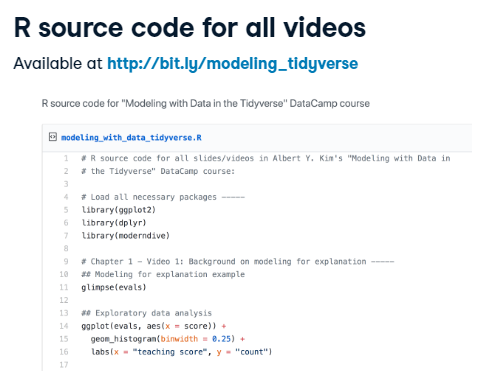

[figure not shown]

link to Tidyverse courses is [here](https://www.datacamp.com/tidyverse-tutorials)

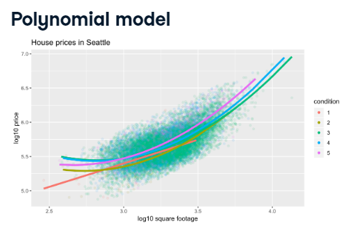

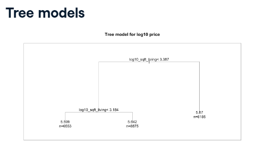

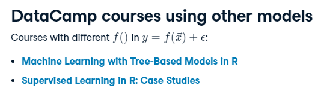

[figure not shown]